# Data Analysis - Student Shapers

```python
import numpy as np
import pandas as pd
import datetime
from scipy import stats
import matplotlib.pyplot as plt
from tabulate import tabulate
from google.colab import drive
import seaborn as sns
drive.mount('/content/drive')
#import locale
```

## Import data

### Panopto

```python
# Import panopto data
# NB 'PanoptoModuleCode' is dropped since id doesnt occur in 20-21 data
df_pan1 = pd.read_csv('/content/drive/MyDrive/student_shapers_data/Panopto20-21v3.csv')
df_pan2 = pd.read_csv('/content/drive/MyDrive/student_shapers_data/Panopto18-19_19-20v3.csv').drop('PanoptoModuleCode', axis=1)
df_pan = pd.concat([df_pan1,df_pan2], ignore_index=True) # Concatenating data

df_pan
```

|  | Id | CURRENT_YEAR_OF_PROGRAMME | ACAD_YEAR | MODULE_TITLE | MODULE_STATUS | CombinedCode | PanoptoFolderName | SessionName | ViewsAndDownloads | MinutesDelivered | AverageMinutesDelivered | PercentCompleted | LastViewTime | LastPosition |
| --- | --- | --- | --- | --- | --- | --- | --- | --- | --- | --- | --- | --- | --- | --- |
| 0 | 10061 | Year 3 | 2018 | Mathematical Computation | Registered for degree credit | MATH94002 | NaN | NaN | NaN | NaN | NaN | NaN | NaN | NaN |
| 1 | 10061 | Year 3 | 2018 | Foundations of Analysis | Registered for degree credit | MATH94003 | NaN | NaN | NaN | NaN | NaN | NaN | NaN | NaN |
| 2 | 10061 | Year 3 | 2018 | Geometry and Linear Algebra | Registered for degree credit | MATH94004 | NaN | NaN | NaN | NaN | NaN | NaN | NaN | NaN |
| 3 | 10061 | Year 3 | 2018 | Analysis 1 | Registered for degree credit | MATH94009 | NaN | NaN | NaN | NaN | NaN | NaN | NaN | NaN |
| 4 | 10061 | Year 3 | 2018 | Algebra 1 | Registered for degree credit | MATH94010 | NaN | NaN | NaN | NaN | NaN | NaN | NaN | NaN |
| ... | ... | ... | ... | ... | ... | ... | ... | ... | ... | ... | ... | ... | ... | ... |
| 264417 | 10880 | Year 2 | 2019 | An Introduction to Applied Mathematics | Registered for degree credit | MATH40007 | MATH40007 - An Introduction to Applied Maths A... | An Introduction to Applied Mathematics (Term 2... | 1.0 | 54.416719 | 54.416719 | 83.0 | 05/02/2020 15:00:19 | 2501.863031 |
| 264418 | 10880 | Year 2 | 2019 | An Introduction to Applied Mathematics | Registered for degree credit | MATH40007 | MATH40007 - An Introduction to Applied Maths A... | An Introduction to Applied Mathematics (Term 2... | 1.0 | 49.731010 | 49.731010 | 74.0 | 26/02/2020 20:29:33 | 2895.990049 |
| 264419 | 10880 | Year 2 | 2019 | An Introduction to Applied Mathematics | Registered for degree credit | MATH40007 | MATH40007 - An Introduction to Applied Maths A... | An Introduction to Applied Mathematics (Term 2... | 2.0 | 5.408725 | 2.704363 | 10.0 | 17/05/2020 05:59:16 | 543.278331 |
| 264420 | 10880 | Year 2 | 2019 | An Introduction to Applied Mathematics | Registered for degree credit | MATH40007 | MATH40007 - An Introduction to Applied Maths A... | An Introduction to Applied Mathematics (Term 2... | 1.0 | 49.307598 | 49.307598 | 76.0 | 03/02/2020 14:19:02 | 2970.380773 |
| 264421 | 10880 | Year 2 | 2019 | An Introduction to Applied Mathematics | Registered for degree credit | MATH40007 | MATH40007 - An Introduction to Applied Maths A... | An Introduction to Applied Mathematics (Term 2... | 1.0 | 24.594076 | 24.594076 | 39.0 | 15/01/2020 14:25:53 | 3100.010610 |

264422 rows × 14 columns

```python
temp = df_pan.drop_duplicates(subset=['CombinedCode']).reset_index()
print(temp.MODULE_TITLE.value_counts())
temp[['MODULE_TITLE', 'CombinedCode']].sort_values(by=['MODULE_TITLE'])
```

```
Analysis 1                                                                    2
Statistical Modelling 1                                                       2
Network Science                                                               1
Lebesgue Measure and Integration                                              1
Analysis 2                                                                    1
Statistical Modelling 2                                                       1
Introduction to University Mathematics                                        1
Foundations of Analysis                                                       1
Real Analysis                                                                 1
Mathematics of Business and Economics                                         1
Partial Differential Equations in Action: Modelling in Applied Mathematics    1
Linear Algebra and Numerical Analysis                                         1
Statistical Theory 1                                                          1
Survival Models and Actuarial Applications                                    1
Algebra 2                                                                     1
Calculus and Applications                                                     1
Introduction to Numerical Analysis                                            1
Mathematical Computation                                                      1
Stochastic Simulation                                                         1
Differential Equations                                                        1
Multivariable Calculus and Differential Equations                             1
Algebra 1                                                                     1
Time Series                                                                   1
Groups and Rings                                                              1
Probability and Statistics 1                                                  1
Linear Algebra and Groups                                                     1
Geometry and Linear Algebra                                                   1
Probability for Statistics                                                    1
Multivariable Calculus                                                        1
Probability and Statistics 2                                                  1
An Introduction to Applied Mathematics                                        1
Introduction to Computation                                                   1
Applied Probability                                                           1
Introduction to Statistical Learning                                          1
Probability and Statistics                                                    1
Name: MODULE_TITLE, dtype: int64
```

|  | MODULE_TITLE | CombinedCode |
| --- | --- | --- |
| 4 | Algebra 1 | MATH94010 |
| 6 | Algebra 2 | MATH95006 |
| 26 | An Introduction to Applied Mathematics | MATH40007 |
| 3 | Analysis 1 | MATH94009 |
| 23 | Analysis 1 | MATH40002 |
| 27 | Analysis 2 | MATH50001 |
| 14 | Applied Probability | MATH96052 |
| 21 | Calculus and Applications | MATH40004 |
| 7 | Differential Equations | MATH95001 |
| 1 | Foundations of Analysis | MATH94003 |
| 2 | Geometry and Linear Algebra | MATH94004 |
| 30 | Groups and Rings | MATH50005 |
| 20 | Introduction to Computation | MATH40006 |
| 8 | Introduction to Numerical Analysis | MATH95003 |
| 16 | Introduction to Statistical Learning | MATH96067 |
| 22 | Introduction to University Mathematics | MATH40001 |
| 32 | Lebesgue Measure and Integration | MATH50006 |
| 24 | Linear Algebra and Groups | MATH40003 |
| 28 | Linear Algebra and Numerical Analysis | MATH50003 |
| 0 | Mathematical Computation | MATH94002 |
| 17 | Mathematics of Business and Economics | MATH96011 |
| 9 | Multivariable Calculus | MATH95002 |
| 29 | Multivariable Calculus and Differential Equations | MATH50004 |
| 34 | Network Science | MATH50007 |
| 35 | Partial Differential Equations in Action: Mode... | MATH50008 |
| 25 | Probability and Statistics | MATH40005 |
| 5 | Probability and Statistics 1 | MATH94012 |
| 11 | Probability and Statistics 2 | MATH95011 |
| 31 | Probability for Statistics | MATH50010 |
| 10 | Real Analysis | MATH95005 |
| 33 | Statistical Modelling 1 | MATH50011 |
| 12 | Statistical Modelling 1 | MATH95012 |
| 19 | Statistical Modelling 2 | MATH96051 |
| 18 | Statistical Theory 1 | MATH96046 |
| 13 | Stochastic Simulation | MATH96054 |
| 36 | Survival Models and Actuarial Applications | MATH96048 |
| 15 | Time Series | MATH96053 |

### Blackboard

```python
# Import blackboard data
df_bb = pd.read_csv('/content/drive/MyDrive/student_shapers_data/Blackboard18-19_19-20_20-21.csv')
df_bb
```

|  | Id | CURRENT_YEAR_OF_PROGRAMME | ACAD_YEAR | MODULE_TITLE | MODULE_STATUS | CombinedCode | HoursInBbCourse |
| --- | --- | --- | --- | --- | --- | --- | --- |
| 0 | 10061 | Year 3 | 2018 | Mathematical Computation | Registered for degree credit | MATH94002 | 36.588610 |
| 1 | 10061 | Year 3 | 2018 | Foundations of Analysis | Registered for degree credit | MATH94003 | 39.482777 |
| 2 | 10061 | Year 3 | 2018 | Geometry and Linear Algebra | Registered for degree credit | MATH94004 | 109.853062 |
| 3 | 10061 | Year 3 | 2018 | Analysis 1 | Registered for degree credit | MATH94009 | 19.703887 |
| 4 | 10061 | Year 3 | 2018 | Algebra 1 | Registered for degree credit | MATH94010 | 79.815555 |
| ... | ... | ... | ... | ... | ... | ... | ... |
| 10920 | 11280 | Year 1 | 2020 | Probability and Statistics | Registered for degree credit | MATH40005 | 98.645558 |
| 10921 | 11280 | Year 1 | 2020 | Introduction to Computation | Registered for degree credit | MATH40006 | 60.299168 |
| 10922 | 11280 | Year 1 | 2020 | Introduction to University Mathematics | Registered for degree credit | MATH40001 | 113.556117 |
| 10923 | 11280 | Year 1 | 2020 | Calculus and Applications | Registered for degree credit | MATH40004 | 95.290283 |
| 10924 | 11280 | Year 1 | 2020 | An Introduction to Applied Mathematics | Registered for degree credit | MATH40007 | 72.298337 |

10925 rows × 7 columns

### Student Numbers

```python
df_numbers = pd.read_csv('/content/drive/MyDrive/student_shapers_data/ModuleStudentNumbers18-19_19-20_20-21.csv')
df_numbers
```

|  | ACAD_YEAR | CombinedCode | n |
| --- | --- | --- | --- |
| 0 | 2018 | MATH94002 | 219 |
| 1 | 2018 | MATH94003 | 220 |
| 2 | 2018 | MATH94004 | 219 |
| 3 | 2018 | MATH94009 | 220 |
| 4 | 2018 | MATH94010 | 221 |
| ... | ... | ... | ... |
| 61 | 2020 | MATH96051 | 66 |
| 62 | 2020 | MATH96052 | 149 |
| 63 | 2020 | MATH96053 | 195 |
| 64 | 2020 | MATH96054 | 130 |
| 65 | 2020 | MATH96067 | 114 |

66 rows × 3 columns

## Wrangling data

### Converting CombinedCode to Module Title

df_numbers only shows the size of each class against with module code, however we work with the Module Title, hence lets ammend df_number such that it works with the module title too.

```python
df = df_pan[['MODULE_TITLE', 'CombinedCode']].drop_duplicates(subset=['CombinedCode'])
keys = list(df.CombinedCode)
values = list(df.MODULE_TITLE)
dict_numbers = dict(zip(keys, values))
df_numbers['MODULE_TITLE'] = df_numbers['CombinedCode'].map(dict_numbers)
df_numbers.drop(columns='CombinedCode', inplace=True)
df_numbers
```

|  | ACAD_YEAR | n | MODULE_TITLE |
| --- | --- | --- | --- |
| 0 | 2018 | 219 | Mathematical Computation |
| 1 | 2018 | 220 | Foundations of Analysis |
| 2 | 2018 | 219 | Geometry and Linear Algebra |
| 3 | 2018 | 220 | Analysis 1 |
| 4 | 2018 | 221 | Algebra 1 |
| ... | ... | ... | ... |
| 61 | 2020 | 66 | Statistical Modelling 2 |
| 62 | 2020 | 149 | Applied Probability |
| 63 | 2020 | 195 | Time Series |
| 64 | 2020 | 130 | Stochastic Simulation |
| 65 | 2020 | 114 | Introduction to Statistical Learning |

66 rows × 3 columns

### Number of unique videos

```python
# List of unique videos.
df_uv = df_pan.drop_duplicates(subset=['SessionName'])
df_uv.dropna(inplace=True)
df_uv = df_uv[['MODULE_TITLE', 'SessionName', 'ACAD_YEAR']]
df_uv.sort_values('MODULE_TITLE', inplace=True)
df_uv.to_csv('/content/drive/MyDrive/student_shapers_data/saves/unique_SessionName.csv', index=False)
df_uv
```

|  | MODULE_TITLE | SessionName | ACAD_YEAR |
| --- | --- | --- | --- |
| 199639 | Algebra 1 | M1P2 Revision Class 30/04/19 (Tue) | 2018 |
| 199623 | Algebra 1 | M1P2 - Algebra I Lecture 1 on 30/01/2019 (Wed) | 2018 |
| 199621 | Algebra 1 | M1P2 - Algebra I Lecture 2 on 10/01/2019 (Thu) | 2018 |
| 199620 | Algebra 1 | M1P2 Revision Class 02/05/19 (Thu) | 2018 |
| 199617 | Algebra 1 | M1P2 - Algebra I Lecture 3 on 18/01/2019 (Fri) | 2018 |
| ... | ... | ... | ... |
| 128 | Time Series | TSA Video 36 | 2020 |
| 127 | Time Series | TSA Video 35 | 2020 |
| 126 | Time Series | TSA Video 34 | 2020 |
| 137 | Time Series | TSA Video 7 | 2020 |
| 213050 | Time Series | S8 Time Series Problems Class 4 on 12/12/2018 ... | 2018 |

2580 rows × 3 columns

```python
# Number of unique videos for each module
df_nuv = df_uv.groupby(['MODULE_TITLE', 'ACAD_YEAR']).agg('count')
df_nuv.rename(columns={'SessionName':'number_of_sessions'}, inplace=True)
df_nuv.to_csv('/content/drive/MyDrive/student_shapers_data/saves/num_unique_SessionName.csv')
df_nuv
```

| MODULE_TITLE | ACAD_YEAR | number_of_sessions |
| --- | --- | --- |
| Algebra 1 | 2018 | 32 |
| Algebra 2 | 2018 | 32 |
|  | 2019 | 30 |
| An Introduction to Applied Mathematics | 2019 | 20 |
|  | 2020 | 69 |
| ... | ... | ... |
| Survival Models and Actuarial Applications | 2019 | 32 |
|  | 2020 | 68 |
| Time Series | 2018 | 29 |
|  | 2019 | 30 |
|  | 2020 | 50 |

64 rows × 1 columns

### Dropping columns

```python
print(list(df_pan.columns.values)) # Panopto
print('_'*100)
print(list(df_bb.columns.values)) # Blackboard
```

```
['Id', 'CURRENT_YEAR_OF_PROGRAMME', 'ACAD_YEAR', 'MODULE_TITLE', 'MODULE_STATUS', 'CombinedCode', 'PanoptoFolderName', 'SessionName', 'ViewsAndDownloads', 'MinutesDelivered', 'AverageMinutesDelivered', 'PercentCompleted', 'LastViewTime', 'LastPosition']
____________________________________________________________________________________________________
['Id', 'CURRENT_YEAR_OF_PROGRAMME', 'ACAD_YEAR', 'MODULE_TITLE', 'MODULE_STATUS', 'CombinedCode', 'HoursInBbCourse']
```

Let us drop:

- CURRENT_YEAR_OF_PROGRAMME
- PanoptoFolderName
- SessionName
- AverageMinutesDelivered
- LastPosition

```python
df_pan.drop(['CURRENT_YEAR_OF_PROGRAMME', 'PanoptoFolderName',
         'SessionName', 'AverageMinutesDelivered', 'LastPosition'],
         axis=1, inplace=True)
df_bb.drop(['CURRENT_YEAR_OF_PROGRAMME'],
         axis=1, inplace=True)
```

### Removing those not for credit

```python
print(df_pan.MODULE_STATUS.value_counts()) # Panopto
print('_'*50)
print(df_bb.MODULE_STATUS.value_counts()) # Blackboard
```

```
Registered for degree credit    264198
Registered, non-assessed           187
Registered, non assessed*           37
Name: MODULE_STATUS, dtype: int64
__________________________________________________
Registered for degree credit    10880
Registered, non-assessed           38
Registered, non assessed*           7
Name: MODULE_STATUS, dtype: int64
```

Clearly removing those not for credit results in a small data loss, hence lets do it so we only are analysing students for credit.

First, let us save the number of datapoints.

```python
# Number of data points.
N_pan = len(df_pan.index) # Panopto
N_bb = len(df_bb.index) # Blackboard
```

```python
# Panopto
df_pan = df_pan.loc[df_pan['MODULE_STATUS'] == 'Registered for degree credit']
df_pan.drop('MODULE_STATUS', axis=1, inplace=True)
```

```python
# Blackboard
df_bb = df_bb.loc[df_bb['MODULE_STATUS'] == 'Registered for degree credit']
df_bb.drop('MODULE_STATUS', axis=1, inplace=True)
```

### Removing NaNs

```python
print(df_pan.info()) # Panopto
print('_'*50)
print(df_bb.info()) # Blackboard
```

```
<class 'pandas.core.frame.DataFrame'>
Int64Index: 264198 entries, 0 to 264421
Data columns (total 8 columns):
 #   Column             Non-Null Count   Dtype
---  ------             --------------   -----
 0   Id                 264198 non-null  int64
 1   ACAD_YEAR          264198 non-null  int64
 2   MODULE_TITLE       264198 non-null  object
 3   CombinedCode       264198 non-null  object
 4   ViewsAndDownloads  256303 non-null  float64
 5   MinutesDelivered   256303 non-null  float64
 6   PercentCompleted   256111 non-null  float64
 7   LastViewTime       256303 non-null  object
dtypes: float64(3), int64(2), object(3)
memory usage: 18.1+ MB
None
__________________________________________________
<class 'pandas.core.frame.DataFrame'>
Int64Index: 10880 entries, 0 to 10924
Data columns (total 5 columns):
 #   Column           Non-Null Count  Dtype
---  ------           --------------  -----
 0   Id               10880 non-null  int64
 1   ACAD_YEAR        10880 non-null  int64
 2   MODULE_TITLE     10880 non-null  object
 3   CombinedCode     10880 non-null  object
 4   HoursInBbCourse  10790 non-null  float64
dtypes: float64(1), int64(2), object(2)
memory usage: 510.0+ KB
None
```

Clearly removing the NaNs again results in a small data loss, hence lets drop them.

```python
df_pan.dropna(inplace=True)
df_bb.dropna(inplace=True)
```

### Converting LastViewTime to viewed in revision period or exam period.

```python
#locale.getlocale()
# Format doesnt have to be specified, however it takes much longer
df_pan['LastViewTime'] =  pd.to_datetime(df_pan['LastViewTime']).dt.date
```

Now let us convert the LastView time into binary

- 1 : Lecture last viewed before the end of term 2
- 0 : Lecture last viewed after term 2

```python
# 18-19 academic year
spring19_end = datetime.date(year=2019,month=3,day=18)

# 19-20 academic year
spring20_end = datetime.date(year=2020,month=3,day=16)

# 20-21 academic year
spring21_end = datetime.date(year=2021,month=3,day=26)


### 18-19
year_cond = (df_pan['ACAD_YEAR'] == 2018)
lectures19 = (year_cond) & (df_pan['LastViewTime'] <= spring19_end)
exams19 = (year_cond) & (df_pan['LastViewTime'] > spring19_end)
### 19-20
year_cond = (df_pan['ACAD_YEAR'] == 2019)
lectures20 = (year_cond) & (df_pan['LastViewTime'] <= spring20_end)
exams20 = (year_cond) & (df_pan['LastViewTime'] > spring20_end)


### 20-21
year_cond = (df_pan['ACAD_YEAR'] == 2020)
lectures21 = (year_cond) & (df_pan['LastViewTime'] <= spring21_end)
exams21 = (year_cond) & (df_pan['LastViewTime'] > spring21_end)



df_pan.loc[lectures19 | lectures20 | lectures21, 'LastViewTime'] = 1
df_pan.loc[exams19 | exams20 | exams21, 'LastViewTime'] = 0

# Convert to float to allow arithmetic to be performed
df_pan['LastViewTime'] = pd.to_numeric(df_pan['LastViewTime'], downcast='float')
df_pan.LastViewTime.value_counts()
```

```
1.0    217617
0.0     38494
Name: LastViewTime, dtype: int64
```

Overall we have kept:

```python
print(len(df_pan.index)/N_pan, 'total panopto data kept')
print('_'*50)
print(len(df_bb.index)/N_bb, 'total blackboard data kept')
```

```
0.9685691810817557 total panopto data kept
__________________________________________________
0.9876430205949657 total blackboard data kept
```

Let us view the data:

```python
df_pan
```

|  | Id | ACAD_YEAR | MODULE_TITLE | CombinedCode | ViewsAndDownloads | MinutesDelivered | PercentCompleted | LastViewTime |
| --- | --- | --- | --- | --- | --- | --- | --- | --- |
| 38 | 11507 | 2020 | Stochastic Simulation | MATH96054 | 3.0 | 9.830859 | 77.0 | 1.0 |
| 39 | 11507 | 2020 | Stochastic Simulation | MATH96054 | 2.0 | 19.893870 | 100.0 | 1.0 |
| 40 | 11507 | 2020 | Stochastic Simulation | MATH96054 | 3.0 | 15.835799 | 96.0 | 1.0 |
| 41 | 11507 | 2020 | Stochastic Simulation | MATH96054 | 4.0 | 22.595881 | 69.0 | 1.0 |
| 42 | 11507 | 2020 | Stochastic Simulation | MATH96054 | 6.0 | 5.699108 | 79.0 | 0.0 |
| ... | ... | ... | ... | ... | ... | ... | ... | ... |
| 264417 | 10880 | 2019 | An Introduction to Applied Mathematics | MATH40007 | 1.0 | 54.416719 | 83.0 | 0.0 |
| 264418 | 10880 | 2019 | An Introduction to Applied Mathematics | MATH40007 | 1.0 | 49.731010 | 74.0 | 1.0 |
| 264419 | 10880 | 2019 | An Introduction to Applied Mathematics | MATH40007 | 2.0 | 5.408725 | 10.0 | 0.0 |
| 264420 | 10880 | 2019 | An Introduction to Applied Mathematics | MATH40007 | 1.0 | 49.307598 | 76.0 | 1.0 |
| 264421 | 10880 | 2019 | An Introduction to Applied Mathematics | MATH40007 | 1.0 | 24.594076 | 39.0 | 1.0 |

256111 rows × 8 columns

```python
df_bb
```

|  | Id | ACAD_YEAR | MODULE_TITLE | CombinedCode | HoursInBbCourse |
| --- | --- | --- | --- | --- | --- |
| 0 | 10061 | 2018 | Mathematical Computation | MATH94002 | 36.588610 |
| 1 | 10061 | 2018 | Foundations of Analysis | MATH94003 | 39.482777 |
| 2 | 10061 | 2018 | Geometry and Linear Algebra | MATH94004 | 109.853062 |
| 3 | 10061 | 2018 | Analysis 1 | MATH94009 | 19.703887 |
| 4 | 10061 | 2018 | Algebra 1 | MATH94010 | 79.815555 |
| ... | ... | ... | ... | ... | ... |
| 10920 | 11280 | 2020 | Probability and Statistics | MATH40005 | 98.645558 |
| 10921 | 11280 | 2020 | Introduction to Computation | MATH40006 | 60.299168 |
| 10922 | 11280 | 2020 | Introduction to University Mathematics | MATH40001 | 113.556117 |
| 10923 | 11280 | 2020 | Calculus and Applications | MATH40004 | 95.290283 |
| 10924 | 11280 | 2020 | An Introduction to Applied Mathematics | MATH40007 | 72.298337 |

10790 rows × 5 columns

### Aggregating Panopto data by module, Id and academic year

The panopto data contains information of each video howeverr to make this data more managable lets consider only the different modules.

```python
df_pan.ACAD_YEAR.value_counts() # Notice far more videos for AY20-21
```

```
2020    191108
2019     39032
2018     25971
Name: ACAD_YEAR, dtype: int64
```

```python
df_pan = df_pan.groupby(['Id', 'MODULE_TITLE', 'ACAD_YEAR']).agg({'ViewsAndDownloads': 'mean',
                             'MinutesDelivered': np.sum,
                             'PercentCompleted':'mean',
                             'LastViewTime': 'mean'}).reset_index()
df_pan.rename(columns={"ViewsAndDownloads": "AvgViewsAndDownloads", "LastViewTime": "PropTermTimeLastView"}, inplace=True)
df_pan
```

|  | Id | MODULE_TITLE | ACAD_YEAR | AvgViewsAndDownloads | MinutesDelivered | PercentCompleted | PropTermTimeLastView |
| --- | --- | --- | --- | --- | --- | --- | --- |
| 0 | 10001 | Statistical Modelling 2 | 2018 | 2.157895 | 469.904704 | 32.684211 | 0.157895 |
| 1 | 10001 | Stochastic Simulation | 2019 | 2.000000 | 116.322180 | 20.230769 | 0.230769 |
| 2 | 10001 | Time Series | 2019 | 1.812500 | 199.039144 | 24.312500 | 0.937500 |
| 3 | 10002 | An Introduction to Applied Mathematics | 2019 | 1.250000 | 367.919891 | 56.416667 | 0.833333 |
| 4 | 10002 | Analysis 1 | 2019 | 1.400000 | 424.125811 | 52.866667 | 0.600000 |
| ... | ... | ... | ... | ... | ... | ... | ... |
| 9491 | 11667 | Multivariable Calculus and Differential Equations | 2020 | 1.200000 | 64.080669 | 40.400000 | 1.000000 |
| 9492 | 11667 | Partial Differential Equations in Action: Mode... | 2020 | 1.500000 | 0.904835 | 4.000000 | 1.000000 |
| 9493 | 11667 | Probability and Statistics | 2019 | 1.500000 | 10.400279 | 7.125000 | 0.125000 |
| 9494 | 11667 | Probability for Statistics | 2020 | 1.333333 | 2.613448 | 7.666667 | 1.000000 |
| 9495 | 11667 | Statistical Modelling 1 | 2020 | 1.090909 | 79.671695 | 55.363636 | 1.000000 |

9496 rows × 7 columns

```python
df_pan.ACAD_YEAR.value_counts()
```

```
2020    3873
2019    3390
2018    2233
Name: ACAD_YEAR, dtype: int64
```

### Merge Data

```python
df = pd.merge(df_pan, df_bb, how='outer', on=['Id', 'MODULE_TITLE', 'ACAD_YEAR'])
```

### Adding the year group

Let us begin by viewing all the different modules

```python
all_modules = set(df.MODULE_TITLE)
all_modules
```

```
{'Algebra 1',
 'Algebra 2',
 'An Introduction to Applied Mathematics',
 'Analysis 1',
 'Analysis 2',
 'Applied Probability',
 'Calculus and Applications',
 'Differential Equations',
 'Foundations of Analysis',
 'Geometry and Linear Algebra',
 'Groups and Rings',
 'Introduction to Computation',
 'Introduction to Numerical Analysis',
 'Introduction to Statistical Learning',
 'Introduction to University Mathematics',
 'Lebesgue Measure and Integration',
 'Linear Algebra and Groups',
 'Linear Algebra and Numerical Analysis',
 'Mathematical Computation',
 'Mathematics of Business and Economics',
 'Multivariable Calculus',
 'Multivariable Calculus and Differential Equations',
 'Network Science',
 'Partial Differential Equations in Action: Modelling in Applied Mathematics',
 'Probability and Statistics',
 'Probability and Statistics 1',
 'Probability and Statistics 2',
 'Probability for Statistics',
 'Real Analysis',
 'Statistical Modelling 1',
 'Statistical Modelling 2',
 'Statistical Theory 1',
 'Stochastic Simulation',
 'Survival Models and Actuarial Applications',
 'Time Series'}
```

Let us create a dictionary assigning all year one modules to 1, year 2 modules to to and year 3/4 modules to 3. And then apply it creating a new column: year.

```python
yr1 = ['An Introduction to Applied Mathematics',
       'Analysis 1',
       'Calculus and Applications',
       'Introduction to Computation',
       'Introduction to University Mathematics',
       'Linear Algebra and Groups',
       'Probability and Statistics',
       'Algebra 1',
       'Foundations of Analysis',
       'Geometry and Linear Algebra',
       'Probability and Statistics 1',
       'Mathematical Computation',
       ]
yr2 = ['Analysis 2',
       'Linear Algebra and Numerical Analysis',
       'Multivariable Calculus and Differential Equations',
       'Network Science',
       'Partial Differential Equations in Action: Modelling in Applied Mathematics',
       'Probability for Statistics',
       'Algebra 2',
       'Differential Equations',
       'Introduction to Numerical Analysis',
       'Multivariable Calculus',
       'Probability and Statistics 2',
       'Real Analysis',
       'Statistical Modelling 1',
       'Lebesgue Measure and Integration',
       'Groups and Rings',
       ]
yr3 = all_modules - set(yr2) - set(yr1)

dict_year = dict.fromkeys(yr1, 1)
dict_year.update(dict.fromkeys(yr2, 2))
dict_year.update(dict.fromkeys(yr3, 3))
df['year'] = df['MODULE_TITLE'].map(dict_year)
```

### Adding whether modules are compulsory

We do a similar thing, creating a dictionary then using it to create another column: compulsory. Where 1 = compulsory module, 0 = elective module.

```python
dict_comp = {'Statistical Modelling 2': 0,
 'Stochastic Simulation': 0,
 'Time Series': 0,
 'An Introduction to Applied Mathematics': 1,
 'Analysis 1': 1,
 'Analysis 2': 1,
 'Calculus and Applications': 1,
 'Introduction to Computation': 1,
 'Introduction to University Mathematics': 1,
 'Linear Algebra and Groups': 1,
 'Linear Algebra and Numerical Analysis': 1,
 'Multivariable Calculus and Differential Equations': 1,
 'Network Science': 0,
 'Partial Differential Equations in Action: Modelling in Applied Mathematics': 0,
 'Probability and Statistics': 1,
 'Probability for Statistics': 0,
 'Algebra 1': 1,
 'Algebra 2': 1,
 'Applied Probability': 0,
 'Differential Equations': 1,
 'Foundations of Analysis': 1,
 'Geometry and Linear Algebra': 1,
 'Introduction to Numerical Analysis': 1,
 'Introduction to Statistical Learning': 0,
 'Multivariable Calculus': 1,
 'Probability and Statistics 1': 1,
 'Probability and Statistics 2': 1,
 'Real Analysis': 1,
 'Statistical Theory 1': 0,
 'Statistical Modelling 1': 0,
 'Lebesgue Measure and Integration': 0,
 'Mathematics of Business and Economics': 0,
 'Groups and Rings': 0,
 'Survival Models and Actuarial Applications': 0,
 'Mathematical Computation': 1,
 }
df['compulsory'] = df['MODULE_TITLE'].map(dict_comp)
```

### Changing data types

Change datatypes to be more memory efficient.

```python
df.info()
```

```
<class 'pandas.core.frame.DataFrame'>
Int64Index: 10865 entries, 0 to 10864
Data columns (total 11 columns):
 #   Column                Non-Null Count  Dtype
---  ------                --------------  -----
 0   Id                    10865 non-null  int64
 1   MODULE_TITLE          10865 non-null  object
 2   ACAD_YEAR             10865 non-null  int64
 3   AvgViewsAndDownloads  9496 non-null   float64
 4   MinutesDelivered      9496 non-null   float64
 5   PercentCompleted      9496 non-null   float64
 6   PropTermTimeLastView  9496 non-null   float32
 7   CombinedCode          10790 non-null  object
 8   HoursInBbCourse       10790 non-null  float64
 9   year                  10865 non-null  int64
 10  compulsory            10865 non-null  int64
dtypes: float32(1), float64(4), int64(4), object(2)
memory usage: 976.2+ KB
```

```python
df['Id'] = pd.to_numeric(df['Id'], downcast='unsigned')
df['year'] = pd.to_numeric(df['year'], downcast='unsigned')
df['compulsory'] = pd.to_numeric(df['compulsory'], downcast='unsigned')
df['ACAD_YEAR'] = pd.to_numeric(df['ACAD_YEAR'], downcast='unsigned')
df['AvgViewsAndDownloads'] = pd.to_numeric(df['AvgViewsAndDownloads'], downcast='float')
df['MinutesDelivered'] = pd.to_numeric(df['MinutesDelivered'], downcast='float')
df['PercentCompleted'] = pd.to_numeric(df['PercentCompleted'], downcast='float')
df['HoursInBbCourse'] = pd.to_numeric(df['HoursInBbCourse'], downcast='float')
print(df.info())
```

```
<class 'pandas.core.frame.DataFrame'>
Int64Index: 10865 entries, 0 to 10864
Data columns (total 11 columns):
 #   Column                Non-Null Count  Dtype
---  ------                --------------  -----
 0   Id                    10865 non-null  uint16
 1   MODULE_TITLE          10865 non-null  object
 2   ACAD_YEAR             10865 non-null  uint16
 3   AvgViewsAndDownloads  9496 non-null   float32
 4   MinutesDelivered      9496 non-null   float32
 5   PercentCompleted      9496 non-null   float32
 6   PropTermTimeLastView  9496 non-null   float32
 7   CombinedCode          10790 non-null  object
 8   HoursInBbCourse       10790 non-null  float32
 9   year                  10865 non-null  uint8
 10  compulsory            10865 non-null  uint8
dtypes: float32(5), object(2), uint16(2), uint8(2)
memory usage: 530.5+ KB
None
```

### Remove certain module information

```python
pan_cov = ['AvgViewsAndDownloads',
           'MinutesDelivered',
           'PercentCompleted',
           'PropTermTimeLastView',
           ]
bb_cov = ['HoursInBbCourse',
          ]
```

```python
df_all = df.copy()

# Bad Panopto and Bb Data ie modules that used other resouces
cond_bad_pan = df['CombinedCode']=='MATH40007'
cond_bad_bb = (df['MODULE_TITLE']=='Algebra 2') & (df['ACAD_YEAR'] is 2018 or 2019)

df.loc[cond_bad_bb, bb_cov] = np.nan
df.loc[cond_bad_pan, pan_cov] = np.nan
```

### Removing Outliers

```python
# FOR df_all
cols = ['AvgViewsAndDownloads',
 'PercentCompleted',
 'PropTermTimeLastView',
 'HoursInBbCourse'] # Columns to check for outliers

# Data is NOT an outlier if it is a NAN or if it achieves a |zscore| of less than 3
cond_kept = ((df_all[cols].isna()) | (np.abs(stats.zscore(df_all[cols], nan_policy='omit')) < 3))

#Q1 = df_all[cols].quantile(0.25)
#Q3 = df_all[cols].quantile(0.75)
#IQR = Q3 - Q1
#cond_kept = (df_all[cols].isna()) | ((df_all[cols] >= (Q1 - 1.5*IQR)) & (df_all[cols] <= (Q3 + 1.5*IQR)))



cond_all = cond_kept.all(axis=1)
outliers = df_all[~cond_all]
percent_outliers = 1 - sum(cond_all)/len(df_all.index)
percent_outliers *= 100

print(percent_outliers, '% outliers')
print(len(outliers.index), 'num outliers')
df_all = df_all.loc[cond_all] # Update df_all
```

```
2.9268292682926855 % outliers
318 num outliers
```

```python
# FOR df
cols = ['AvgViewsAndDownloads',
 'PercentCompleted',
 'PropTermTimeLastView',
 'HoursInBbCourse'] # Columns to check for outliers

# Data is NOT an outlier if it is a NAN or if it achieves a |zscore| of less than 3
cond_kept = ((df[cols].isna()) | (np.abs(stats.zscore(df[cols], nan_policy='omit')) < 3))

#Q1 = df[cols].quantile(0.25)
#Q3 = df[cols].quantile(0.75)
#IQR = Q3 - Q1
#cond_kept = (df[cols].isna()) | ((df[cols] >= (Q1 - 1.5*IQR)) & (df[cols] <= (Q3 + 1.5*IQR)))



cond_all = cond_kept.all(axis=1)
outliers_removed = df[~cond_all]
percent_outliers = 1 - sum(cond_all)/len(df.index)
percent_outliers *= 100

print(percent_outliers, '% outliers')
print(len(outliers_removed.index), 'num outliers')
df = df.loc[cond_all] # Update df
```

```
2.8439944776806225 % outliers
309 num outliers
```

```python
outliers
```

|  | Id | MODULE_TITLE | ACAD_YEAR | AvgViewsAndDownloads | MinutesDelivered | PercentCompleted | PropTermTimeLastView | CombinedCode | HoursInBbCourse | year | compulsory |
| --- | --- | --- | --- | --- | --- | --- | --- | --- | --- | --- | --- |
| 45 | 10009 | Analysis 1 | 2020 | 4.36 | 686.109497 | 75.959999 | 1.0 | MATH40002 | 39.737225 | 1 | 1 |
| 58 | 10012 | Analysis 1 | 2019 | 2.00 | 53.861900 | 100.000000 | 0.0 | MATH40002 | 498.453339 | 1 | 1 |
| 60 | 10012 | Calculus and Applications | 2019 | 1.25 | 12.542649 | 21.500000 | 0.5 | MATH40004 | 384.593323 | 1 | 1 |
| 61 | 10012 | Introduction to University Mathematics | 2019 | 1.50 | 40.612347 | 15.166667 | 1.0 | MATH40001 | 967.582214 | 1 | 1 |
| 63 | 10012 | Linear Algebra and Groups | 2019 | 1.00 | 1.386255 | 6.000000 | 0.0 | MATH40003 | 344.115265 | 1 | 1 |
| ... | ... | ... | ... | ... | ... | ... | ... | ... | ... | ... | ... |
| 10828 | 10085 | Calculus and Applications | 2019 | NaN | NaN | NaN | NaN | MATH40004 | 454.223053 | 1 | 1 |
| 10833 | 11294 | Calculus and Applications | 2019 | NaN | NaN | NaN | NaN | MATH40004 | 318.683624 | 1 | 1 |
| 10834 | 11294 | Probability and Statistics | 2019 | NaN | NaN | NaN | NaN | MATH40005 | 319.369446 | 1 | 1 |
| 10839 | 11494 | Introduction to University Mathematics | 2019 | NaN | NaN | NaN | NaN | MATH40001 | 506.688049 | 1 | 1 |
| 10863 | 11112 | An Introduction to Applied Mathematics | 2020 | NaN | NaN | NaN | NaN | MATH40007 | 690.192200 | 1 | 1 |

318 rows × 11 columns

## Analysis

#### All data

```python
keys = list(df.columns.values) + ['AvgMinutesDeliveredpp',
                                  'AvgMinutesDeliveredPerPerson',
                                  'AvgPercentCompleted',
                                  'AvgHoursInBbCourse',
                                  'n'
                                  ]
values = ['Id',
          'Module Title',
          'Academic Year',
          'Average views',
          'Minutes Delivered',
          'Percent Watched',
          'Proportion of last views during term time',
          'Module Code',
          'Hours on Blackboard',
          'Year group',
          'Compulsory (binary)',
          'Average Minutes Delivered Per Person',
          'Average Minutes Delivered Per Person',
          'Average Percent Watched',
          'Average Hours on Blackboard',
          'Class size',
          ]
dict_names = dict(zip(keys, values))
```

```python
df.to_csv('/content/drive/MyDrive/student_shapers_data/saves/data_all.csv')
foo = ['Id', 'ACAD_YEAR', 'year', 'compulsory']
bar = df.copy()
bar[foo] = df[foo].astype(object)
df_ss = bar.describe(include='all').round(3)
df_ss.rename(columns=dict_names, inplace=True)
df_ss.to_csv('/content/drive/MyDrive/student_shapers_data/saves/data_all_summary_stat.csv')
df_ss
```

|  | Id | Module Title | Academic Year | Average views | Minutes Delivered | Percent Watched | Proportion of last views during term time | Module Code | Hours on Blackboard | Year group | Compulsory (binary) |
| --- | --- | --- | --- | --- | --- | --- | --- | --- | --- | --- | --- |
| count | 10556.0 | 10556 | 10556.0 | 8958.000 | 8958.000 | 8958.000 | 8958.000 | 10482 | 10067.000 | 10556.0 | 10556.0 |
| unique | 1076.0 | 35 | 3.0 | NaN | NaN | NaN | NaN | 37 | NaN | 3.0 | 2.0 |
| top | 11609.0 | Analysis 1 | 2020.0 | NaN | NaN | NaN | NaN | MATH40007 | NaN | 1.0 | 1.0 |
| freq | 19.0 | 680 | 4166.0 | NaN | NaN | NaN | NaN | 497 | NaN | 4608.0 | 7802.0 |
| mean | NaN | NaN | NaN | 1.693 | 601.969 | 61.683 | 0.783 | NaN | 65.470 | NaN | NaN |
| std | NaN | NaN | NaN | 0.588 | 581.856 | 29.714 | 0.290 | NaN | 56.774 | NaN | NaN |
| min | NaN | NaN | NaN | 1.000 | 0.018 | 1.000 | 0.000 | NaN | 0.000 | NaN | NaN |
| 25% | NaN | NaN | NaN | 1.250 | 116.567 | 38.089 | 0.636 | NaN | 24.825 | NaN | NaN |
| 50% | NaN | NaN | NaN | 1.569 | 436.560 | 66.824 | 0.933 | NaN | 48.880 | NaN | NaN |
| 75% | NaN | NaN | NaN | 2.000 | 931.534 | 88.742 | 1.000 | NaN | 88.881 | NaN | NaN |
| max | NaN | NaN | NaN | 4.067 | 5400.696 | 100.000 | 1.000 | NaN | 319.369 | NaN | NaN |

```python
df
```

|  | Id | MODULE_TITLE | ACAD_YEAR | AvgViewsAndDownloads | MinutesDelivered | PercentCompleted | PropTermTimeLastView | CombinedCode | HoursInBbCourse | year | compulsory |
| --- | --- | --- | --- | --- | --- | --- | --- | --- | --- | --- | --- |
| 0 | 10001 | Statistical Modelling 2 | 2018 | 2.157895 | 469.904694 | 32.684212 | 0.157895 | MATH96051 | 42.586941 | 3 | 0 |
| 1 | 10001 | Stochastic Simulation | 2019 | 2.000000 | 116.322182 | 20.230770 | 0.230769 | MATH96054 | 20.528332 | 3 | 0 |
| 2 | 10001 | Time Series | 2019 | 1.812500 | 199.039139 | 24.312500 | 0.937500 | MATH96053 | 21.981939 | 3 | 0 |
| 3 | 10002 | An Introduction to Applied Mathematics | 2019 | NaN | NaN | NaN | NaN | MATH40007 | 93.064720 | 1 | 1 |
| 4 | 10002 | Analysis 1 | 2019 | 1.400000 | 424.125824 | 52.866665 | 0.600000 | MATH40002 | 294.111389 | 1 | 1 |
| ... | ... | ... | ... | ... | ... | ... | ... | ... | ... | ... | ... |
| 10859 | 11627 | An Introduction to Applied Mathematics | 2020 | NaN | NaN | NaN | NaN | MATH40007 | 32.789997 | 1 | 1 |
| 10860 | 11569 | An Introduction to Applied Mathematics | 2020 | NaN | NaN | NaN | NaN | MATH40007 | 0.010000 | 1 | 1 |
| 10861 | 11033 | Introduction to Computation | 2020 | NaN | NaN | NaN | NaN | MATH40006 | 24.262777 | 1 | 1 |
| 10862 | 11033 | An Introduction to Applied Mathematics | 2020 | NaN | NaN | NaN | NaN | MATH40007 | 12.294165 | 1 | 1 |
| 10864 | 11280 | An Introduction to Applied Mathematics | 2020 | NaN | NaN | NaN | NaN | MATH40007 | 72.298340 | 1 | 1 |

10556 rows × 11 columns

### Grouping and Aggregating data

Below the data is grouped by Module title, Id, year (as well as Academic year).

#### By module

```python
df_module = df.groupby(['MODULE_TITLE', 'ACAD_YEAR']).agg({'AvgViewsAndDownloads': 'mean',
                             'MinutesDelivered': 'mean',
                             'PercentCompleted':'mean',
                             'PropTermTimeLastView': 'mean',
                             'HoursInBbCourse': 'mean'}).reset_index()
df_module.rename(columns={'MinutesDelivered': 'AvgMinutesDeliveredpp', 'PercentCompleted': 'AvgPercentCompleted', "HoursInBbCourse": "AvgHoursInBbCourse"}, inplace=True)
df_module = pd.merge(df_module, df_numbers, how='outer', on=['MODULE_TITLE', 'ACAD_YEAR'])
df_module.to_csv('/content/drive/MyDrive/student_shapers_data/saves/data_by_module.csv')
# Omitting non-panopto modules by drop na
df_ss = df_module.drop(columns=['MODULE_TITLE','ACAD_YEAR']).describe(include='all').round(3)
df_ss.rename(columns=dict_names, inplace=True)
df_ss.to_csv('/content/drive/MyDrive/student_shapers_data/saves/data_by_module_summary_stat.csv')
df_ss
```

|  | Average views | Average Minutes Delivered Per Person | Average Percent Watched | Proportion of last views during term time | Average Hours on Blackboard | Class size |
| --- | --- | --- | --- | --- | --- | --- |
| count | 62.000 | 62.000 | 62.000 | 62.000 | 64.000 | 66.00 |
| mean | 1.694 | 554.283 | 59.646 | 0.738 | 58.270 | 165.53 |
| std | 0.200 | 304.363 | 19.565 | 0.198 | 28.632 | 80.78 |
| min | 1.302 | 18.415 | 13.991 | 0.074 | 25.016 | 8.00 |
| 25% | 1.577 | 389.197 | 46.581 | 0.598 | 38.068 | 92.00 |
| 50% | 1.703 | 479.802 | 53.596 | 0.802 | 48.884 | 204.00 |
| 75% | 1.806 | 669.285 | 80.804 | 0.886 | 65.585 | 230.75 |
| max | 2.389 | 1404.682 | 89.012 | 0.998 | 148.362 | 267.00 |

```python
df_module
```

|  | MODULE_TITLE | ACAD_YEAR | AvgViewsAndDownloads | AvgMinutesDeliveredpp | AvgPercentCompleted | PropTermTimeLastView | AvgHoursInBbCourse | n |
| --- | --- | --- | --- | --- | --- | --- | --- | --- |
| 0 | Algebra 1 | 2018 | 1.709071 | 546.050110 | 54.372192 | 0.585269 | 43.459732 | 221 |
| 1 | Algebra 2 | 2018 | 1.736846 | 399.560760 | 47.398949 | 0.802386 | NaN | 204 |
| 2 | Algebra 2 | 2019 | 1.536847 | 404.522430 | 50.692440 | 0.874016 | NaN | 218 |
| 3 | An Introduction to Applied Mathematics | 2019 | NaN | NaN | NaN | NaN | 61.948364 | 234 |
| 4 | An Introduction to Applied Mathematics | 2020 | NaN | NaN | NaN | NaN | 50.346054 | 267 |
| ... | ... | ... | ... | ... | ... | ... | ... | ... |
| 61 | Survival Models and Actuarial Applications | 2019 | 1.614937 | 660.106262 | 57.333210 | 0.550691 | 57.931801 | 21 |
| 62 | Survival Models and Actuarial Applications | 2020 | 1.475610 | 655.950623 | 88.736488 | 0.820821 | 56.335468 | 47 |
| 63 | Time Series | 2018 | 2.019021 | 460.215210 | 49.202034 | 0.655463 | 38.957668 | 47 |
| 64 | Time Series | 2019 | 1.743902 | 622.550049 | 54.025829 | 0.794667 | 38.283798 | 127 |
| 65 | Time Series | 2020 | 1.776176 | 866.401733 | 89.011757 | 0.843875 | 50.564110 | 195 |

66 rows × 8 columns

#### By Id

```python
df_Id = df.groupby(['Id', 'ACAD_YEAR']).agg({'AvgViewsAndDownloads': 'mean',
                             'MinutesDelivered': 'mean',
                             'PercentCompleted':'mean',
                             'PropTermTimeLastView': 'mean',
                             'HoursInBbCourse': 'mean',
                             }).reset_index()
df_Id.rename(columns={'MinutesDelivered': 'AvgMinutesDeliveredpp', 'PercentCompleted': 'AvgPercentCompleted', "HoursInBbCourse": "AvgHoursInBbCourse"}, inplace=True)
df_Id.to_csv('/content/drive/MyDrive/student_shapers_data/saves/data_by_Id.csv')
df_ss = df_Id.drop(columns=['Id', 'ACAD_YEAR']).describe(include='all').round(3)
df_ss.rename(columns=dict_names, inplace=True)
df_ss.to_csv('/content/drive/MyDrive/student_shapers_data/saves/data_by_Id_summary_stat.csv')
df_ss
```

|  | Average views | Average Minutes Delivered Per Person | Average Percent Watched | Proportion of last views during term time | Average Hours on Blackboard |
| --- | --- | --- | --- | --- | --- |
| count | 1903.000 | 1903.000 | 1903.000 | 1903.000 | 1957.000 |
| mean | 1.688 | 571.637 | 60.498 | 0.763 | 61.591 |
| std | 0.448 | 477.707 | 26.657 | 0.225 | 45.577 |
| min | 1.000 | 0.103 | 1.000 | 0.000 | 0.000 |
| 25% | 1.375 | 159.929 | 39.775 | 0.653 | 28.640 |
| 50% | 1.595 | 448.668 | 60.097 | 0.812 | 49.372 |
| 75% | 1.948 | 895.745 | 84.398 | 0.951 | 82.975 |
| max | 3.889 | 3035.600 | 100.000 | 1.000 | 317.561 |

```python
df_Id
```

|  | Id | ACAD_YEAR | AvgViewsAndDownloads | AvgMinutesDeliveredpp | AvgPercentCompleted | PropTermTimeLastView | AvgHoursInBbCourse |
| --- | --- | --- | --- | --- | --- | --- | --- |
| 0 | 10001 | 2018 | 2.157895 | 469.904694 | 32.684212 | 0.157895 | 44.232780 |
| 1 | 10001 | 2019 | 1.906250 | 157.680664 | 22.271635 | 0.584135 | 21.255135 |
| 2 | 10002 | 2019 | 1.210985 | 189.510849 | 40.719318 | 0.810227 | 164.462692 |
| 3 | 10002 | 2020 | 1.859946 | 1288.906372 | 95.284866 | 0.920011 | 101.158333 |
| 4 | 10004 | 2018 | 2.276124 | 311.700989 | 36.490608 | 0.617183 | 79.537361 |
| ... | ... | ... | ... | ... | ... | ... | ... |
| 1957 | 11665 | 2020 | 1.125992 | 196.311722 | 57.022816 | 0.666667 | 42.336666 |
| 1958 | 11666 | 2018 | 2.000000 | 191.584259 | 31.045454 | 1.000000 | 39.497448 |
| 1959 | 11666 | 2019 | 1.208333 | 118.882912 | 44.750000 | 0.416667 | 47.277313 |
| 1960 | 11667 | 2019 | 1.375000 | 37.614780 | 18.725000 | 0.725000 | 49.564121 |
| 1961 | 11667 | 2020 | 1.382828 | 55.083958 | 30.863060 | 0.833333 | 21.206348 |

1962 rows × 7 columns

#### By Year

```python
df_year = df.groupby(['ACAD_YEAR']).agg({'AvgViewsAndDownloads': 'mean',
                             'MinutesDelivered': 'mean',
                             'PercentCompleted':'mean',
                             'PropTermTimeLastView': 'mean',
                             'HoursInBbCourse': 'mean',
                             }).reset_index()
df_year.rename(columns={'MinutesDelivered': 'AvgMinutesDeliveredPerPerson', 'PercentCompleted': 'AvgPercentCompleted', "HoursInBbCourse": "AvgHoursInBbCourse"}, inplace=True)
df_year.to_csv('/content/drive/MyDrive/student_shapers_data/saves/data_by_year.csv')
df_ss = df_year.drop(columns='ACAD_YEAR').describe(include='all').round(3)
df_ss.rename(columns=dict_names, inplace=True)
df_ss.to_csv('/content/drive/MyDrive/student_shapers_data/saves/data_by_year_summary_stat.csv')
df_ss
```

|  | Average views | Average Minutes Delivered Per Person | Average Percent Watched | Proportion of last views during term time | Average Hours on Blackboard |
| --- | --- | --- | --- | --- | --- |
| count | 3.000 | 3.000 | 3.000 | 3.000 | 3.000 |
| mean | 1.700 | 559.674 | 58.543 | 0.767 | 63.290 |
| std | 0.036 | 275.027 | 20.498 | 0.114 | 16.304 |
| min | 1.671 | 383.231 | 45.528 | 0.696 | 44.487 |
| 25% | 1.680 | 401.227 | 46.729 | 0.701 | 58.192 |
| 50% | 1.688 | 419.223 | 47.929 | 0.706 | 71.897 |
| 75% | 1.714 | 647.895 | 65.050 | 0.802 | 72.692 |
| max | 1.740 | 876.567 | 82.171 | 0.899 | 73.486 |

```python
df_year
```

|  | ACAD_YEAR | AvgViewsAndDownloads | AvgMinutesDeliveredPerPerson | AvgPercentCompleted | PropTermTimeLastView | AvgHoursInBbCourse |
| --- | --- | --- | --- | --- | --- | --- |
| 0 | 2018 | 1.739738 | 383.231171 | 45.527927 | 0.705789 | 44.486740 |
| 1 | 2019 | 1.688059 | 419.222992 | 47.929150 | 0.695958 | 71.897255 |
| 2 | 2020 | 1.670972 | 876.566956 | 82.171326 | 0.898969 | 73.486191 |

### Plots

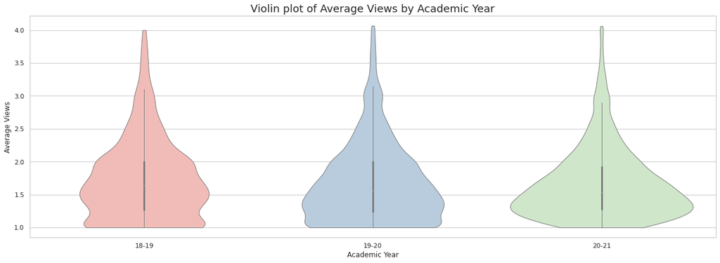

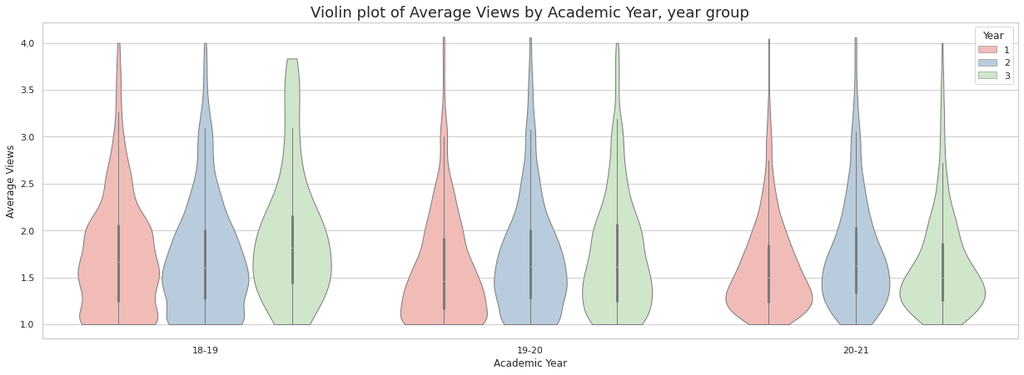

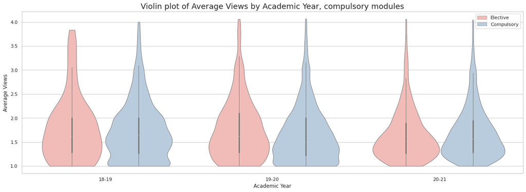

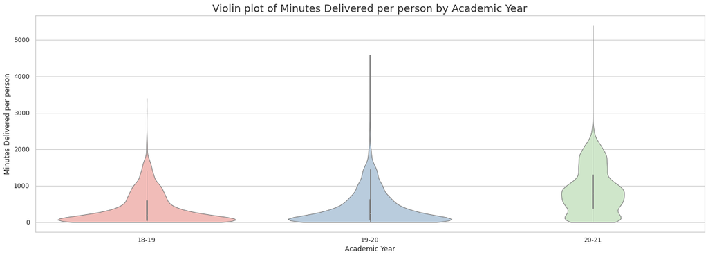

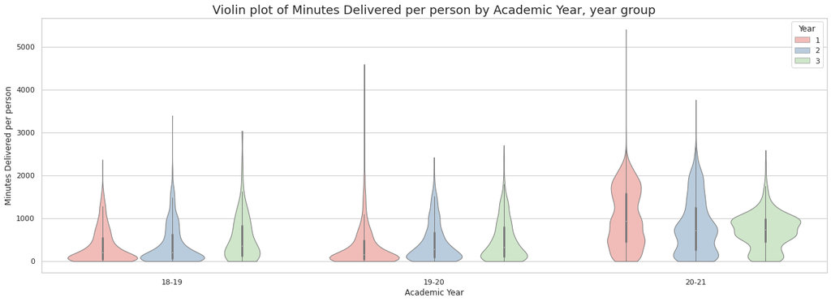

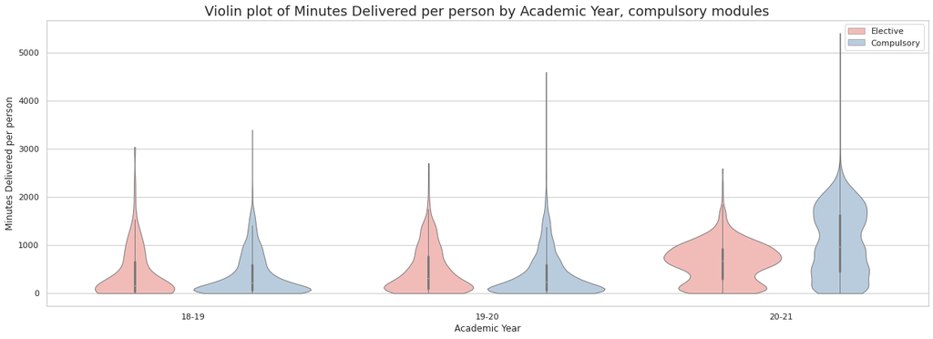

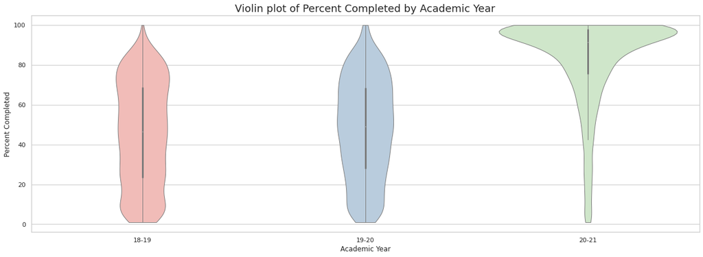

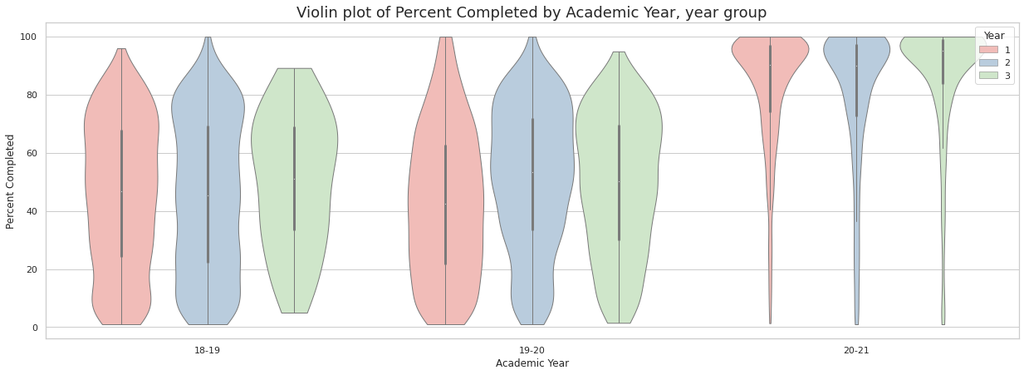

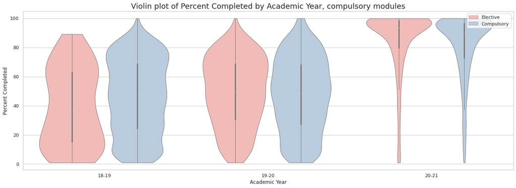

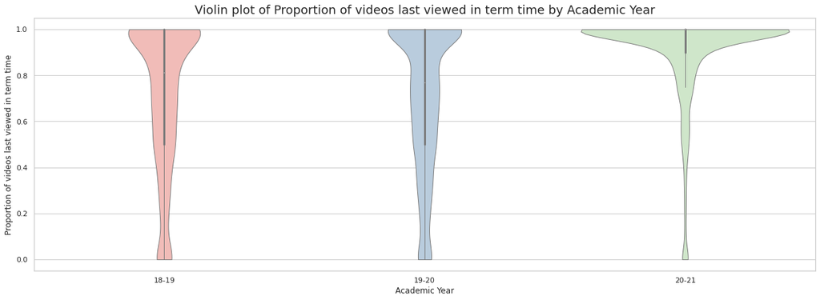

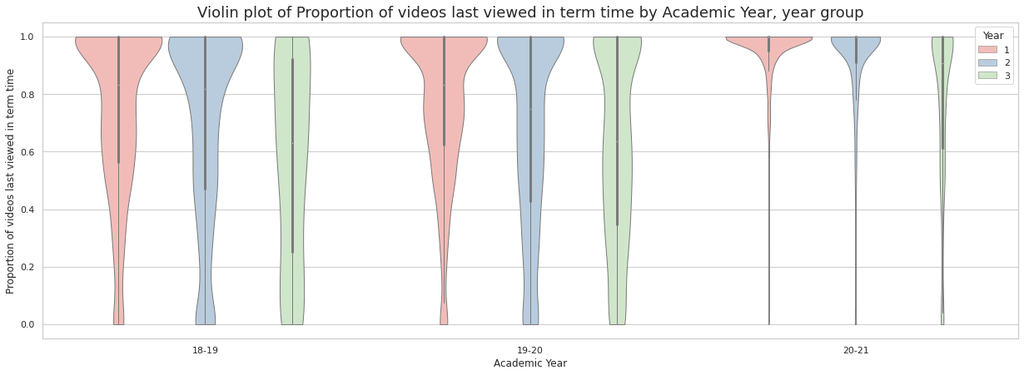

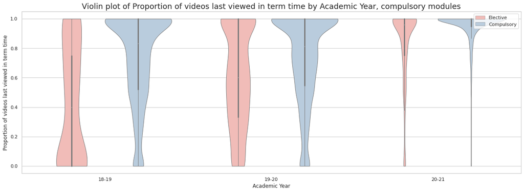

[3 more figures not shown]

```python
dpi = 600
lw = 1
cut = 0
font_size=18

sns.set(rc={'figure.figsize':(21, 7)})
sns.set_theme(style="whitegrid")
covariates = ['AvgViewsAndDownloads',
              'MinutesDelivered',
              'PercentCompleted',
              'PropTermTimeLastView',
              'HoursInBbCourse',
              ]
covariate_names = ['Average Views',
              'Minutes Delivered per person',
              'Percent Completed',
              'Proportion of videos last viewed in term time',
              'Hours In Blackboard',
              ]
for i in range(len(covariates)):
  covariate = covariates[i]
  covariate_name = covariate_names[i]


  sns.violinplot(data=df, x='ACAD_YEAR', y=covariate, palette="Pastel1", linewidth=lw, cut=cut)
  plt.xticks([0, 1, 2], ['18-19', '19-20', '20-21'])
  plt.xlabel('Academic Year')
  plt.ylabel(covariate_name)
  title = 'Violin plot of ' + covariate_name + ' by Academic Year'
  plt.title(title, fontdict = {'fontsize' : font_size})
  name = '/content/drive/MyDrive/student_shapers_data/saves/violin_plots/' + covariate + '_violinplot.pdf'
  plt.savefig(name, dpi=dpi)
  plt.show()

  sns.violinplot(x='ACAD_YEAR', y=covariate, hue='year', data=df, palette="Pastel1", linewidth=lw, cut=cut)
  plt.xticks([0, 1, 2], ['18-19', '19-20', '20-21'])
  plt.xlabel('Academic Year')
  plt.legend(title = 'Year')
  plt.ylabel(covariate_name)
  title = 'Violin plot of ' + covariate_name + ' by Academic Year, year group'
  plt.title(title, fontdict = {'fontsize' : font_size})
  name = '/content/drive/MyDrive/student_shapers_data/saves/violin_plots/' + covariate + '_violinplot_by_year.pdf'
  plt.savefig(name, dpi=dpi)
  plt.show()

  sns.violinplot(x='ACAD_YEAR', y=covariate, hue='compulsory', data=df, palette="Pastel1", linewidth=lw, cut=cut)
  plt.xticks([0, 1, 2], ['18-19', '19-20', '20-21'])
  plt.xlabel('Academic Year')
  handles, labels = plt.gca().get_legend_handles_labels()
  labels = ['Compulsory' if x == '1' else 'Elective' for x in labels]
  plt.legend(handles, labels)
  plt.ylabel(covariate_name)
  title = 'Violin plot of ' + covariate_name + ' by Academic Year, compulsory modules'
  plt.title(title, fontdict = {'fontsize' : font_size})
  name = '/content/drive/MyDrive/student_shapers_data/saves/violin_plots/' + covariate + '_violinplot_by_comp.pdf'
  plt.savefig(name, dpi=dpi)
  plt.show()
```

## Piazza

### Import data

```python
df_pia = pd.read_csv('/content/drive/MyDrive/student_shapers_data/Piazza18-19_19-20_20-21.csv')
df_pia
```

|  | Id | CURRENT_YEAR_OF_PROGRAMME | ACAD_YEAR | MODULE_TITLE | MODULE_STATUS | CombinedCode | days.online | posts | edits.to.posts | answers | edits.to.answers | followups | replies.to.followups | good.question.given | thanks.on.answers.given | helpful.on.followups.given | post.views | poll.votes | live.q.a.upvotes |
| --- | --- | --- | --- | --- | --- | --- | --- | --- | --- | --- | --- | --- | --- | --- | --- | --- | --- | --- | --- |
| 0 | 10061 | Year 3 | 2018 | Mathematical Computation | Registered for degree credit | MATH94002 | NaN | NaN | NaN | NaN | NaN | NaN | NaN | NaN | NaN | NaN | NaN | NaN | NaN |
| 1 | 10061 | Year 3 | 2018 | Foundations of Analysis | Registered for degree credit | MATH94003 | NaN | NaN | NaN | NaN | NaN | NaN | NaN | NaN | NaN | NaN | NaN | NaN | NaN |
| 2 | 10061 | Year 3 | 2018 | Geometry and Linear Algebra | Registered for degree credit | MATH94004 | NaN | NaN | NaN | NaN | NaN | NaN | NaN | NaN | NaN | NaN | NaN | NaN | NaN |
| 3 | 10061 | Year 3 | 2018 | Analysis 1 | Registered for degree credit | MATH94009 | NaN | NaN | NaN | NaN | NaN | NaN | NaN | NaN | NaN | NaN | NaN | NaN | NaN |
| 4 | 10061 | Year 3 | 2018 | Algebra 1 | Registered for degree credit | MATH94010 | NaN | NaN | NaN | NaN | NaN | NaN | NaN | NaN | NaN | NaN | NaN | NaN | NaN |
| ... | ... | ... | ... | ... | ... | ... | ... | ... | ... | ... | ... | ... | ... | ... | ... | ... | ... | ... | ... |
| 10920 | 11280 | Year 1 | 2020 | Probability and Statistics | Registered for degree credit | MATH40005 | NaN | NaN | NaN | NaN | NaN | NaN | NaN | NaN | NaN | NaN | NaN | NaN | NaN |
| 10921 | 11280 | Year 1 | 2020 | Introduction to Computation | Registered for degree credit | MATH40006 | 2.0 | 0.0 | 0.0 | 0.0 | 0.0 | 0.0 | 0.0 | 0.0 | 0.0 | 0.0 | 0.0 | 0.0 | 0.0 |
| 10922 | 11280 | Year 1 | 2020 | Introduction to University Mathematics | Registered for degree credit | MATH40001 | 2.0 | 0.0 | 0.0 | 0.0 | 0.0 | 0.0 | 0.0 | 0.0 | 0.0 | 0.0 | 12.0 | 0.0 | 0.0 |
| 10923 | 11280 | Year 1 | 2020 | Calculus and Applications | Registered for degree credit | MATH40004 | NaN | NaN | NaN | NaN | NaN | NaN | NaN | NaN | NaN | NaN | NaN | NaN | NaN |
| 10924 | 11280 | Year 1 | 2020 | An Introduction to Applied Mathematics | Registered for degree credit | MATH40007 | NaN | NaN | NaN | NaN | NaN | NaN | NaN | NaN | NaN | NaN | NaN | NaN | NaN |

10925 rows × 19 columns

### Wrangle data

```python
N_pia = len(df_pia.index)
```

#### Remove NaNs

```python
df_pia.dropna(inplace=True)
print('Proportion of Nan in Piazza data:', len(df_pia.index) / N_pia)
```

```
Proportion of Nan in Piazza data: 0.2216933638443936
```

#### Remove those not for credit

```python
df_pia = df_pia.loc[df_pia['MODULE_STATUS'] == 'Registered for degree credit']
```

#### Drop columns

```python
df_pia.drop(['ACAD_YEAR',
             'poll.votes',
             'live.q.a.upvotes',
             'MODULE_STATUS',
             'CURRENT_YEAR_OF_PROGRAMME',
             ],
         axis=1, inplace=True)
```

#### Adding year group

```python
df_pia['year'] = df_pia['MODULE_TITLE'].map(dict_year)
```

#### Adding whether modules are compulsory

```python
df_pia['compulsory'] = df_pia['MODULE_TITLE'].map(dict_comp)
```

#### Changing data types

```python
df_pia.info()
```

```
<class 'pandas.core.frame.DataFrame'>
Int64Index: 2420 entries, 42 to 10922
Data columns (total 16 columns):
 #   Column                      Non-Null Count  Dtype
---  ------                      --------------  -----
 0   Id                          2420 non-null   int64
 1   MODULE_TITLE                2420 non-null   object
 2   CombinedCode                2420 non-null   object
 3   days.online                 2420 non-null   float64
 4   posts                       2420 non-null   float64
 5   edits.to.posts              2420 non-null   float64
 6   answers                     2420 non-null   float64
 7   edits.to.answers            2420 non-null   float64
 8   followups                   2420 non-null   float64
 9   replies.to.followups        2420 non-null   float64
 10  good.question.given         2420 non-null   float64
 11  thanks.on.answers.given     2420 non-null   float64
 12  helpful.on.followups.given  2420 non-null   float64
 13  post.views                  2420 non-null   float64
 14  year                        2420 non-null   int64
 15  compulsory                  2420 non-null   int64
dtypes: float64(11), int64(3), object(2)
memory usage: 321.4+ KB
```

```python
cols = [x for x in list(df_pia.columns.values) if x not in ['MODULE_TITLE', 'CombinedCode']]
for col in cols:
  df_pia[col] = pd.to_numeric(df_pia[col], downcast='unsigned')
df_pia.info()
```

```
<class 'pandas.core.frame.DataFrame'>
Int64Index: 2420 entries, 42 to 10922
Data columns (total 16 columns):
 #   Column                      Non-Null Count  Dtype
---  ------                      --------------  -----
 0   Id                          2420 non-null   uint16
 1   MODULE_TITLE                2420 non-null   object
 2   CombinedCode                2420 non-null   object
 3   days.online                 2420 non-null   uint16
 4   posts                       2420 non-null   uint8
 5   edits.to.posts              2420 non-null   uint8
 6   answers                     2420 non-null   uint8
 7   edits.to.answers            2420 non-null   uint8
 8   followups                   2420 non-null   uint8
 9   replies.to.followups        2420 non-null   uint8
 10  good.question.given         2420 non-null   uint8
 11  thanks.on.answers.given     2420 non-null   uint8
 12  helpful.on.followups.given  2420 non-null   uint8
 13  post.views                  2420 non-null   uint16
 14  year                        2420 non-null   uint8
 15  compulsory                  2420 non-null   uint8
dtypes: object(2), uint16(3), uint8(11)
memory usage: 96.9+ KB
```

#### Removing Outliers

```python
#temp = set(df_pia.Id) - set(df.Id)
#print(temp)
#df_pia.loc[df_pia['Id'].isin(temp)]
```

```python
cols = [x for x in cols if x != 'Id']

### iqr method
Q1 = df_pia[cols].quantile(0.25)
Q3 = df_pia[cols].quantile(0.75)
IQR = Q3 - Q1
cond_kept = (df_pia[cols].isna()) | ((df_pia[cols] >= (Q1 - 1.5 * IQR)) & (df_pia[cols] <= (Q3 + 1.5 * IQR)))
cond_all = cond_kept.all(axis=1)
outliers = df_pia[~cond_all]
percent_outliers = len(outliers.index)/len(df_pia.index)
percent_outliers *= 100


print('Outliers by using IQR')
print(percent_outliers, '% outliers')
print(len(outliers.index), 'num outliers')
print('_'*50)
print('_'*50)



### zscore method
# Data is NOT an outlier if it is a NAN or if it achieves a |zscore| of less than 3
cond_kept = ((df_pia[cols].isna()) | (np.abs(stats.zscore(df_pia[cols], nan_policy='omit')) < 3))
cond_all = cond_kept.all(axis=1)
outliers = df_pia[~cond_all]
percent_outliers = len(outliers.index)/len(df_pia.index)
percent_outliers *= 100

#df_pia = df_pia.loc[cond_all] # Update df

print('Outliers by using zscore')
print(percent_outliers, '% outliers')
print(len(outliers.index), 'num outliers')
```

```
Outliers by using IQR
54.049586776859506 % outliers
1308 num outliers
__________________________________________________
__________________________________________________
Outliers by using zscore
9.421487603305785 % outliers
228 num outliers
```

### Analysis

#### All data

```python
list(df_pia.columns.values)
```

```
['Id',
 'MODULE_TITLE',
 'CombinedCode',
 'days.online',
 'posts',
 'edits.to.posts',
 'answers',
 'edits.to.answers',
 'followups',
 'replies.to.followups',
 'good.question.given',
 'thanks.on.answers.given',
 'helpful.on.followups.given',
 'post.views',
 'year',
 'compulsory']
```

```python
keys = list(df_pia.columns.values)
values = ['Id',
          'Module Title',
          'Module Code',
          'Days Online',
          'Posts',
          'Edits to Posts',
          'Answers',
          'Edits to Answers',
          'Followups',
          'Replies to Followups',
          'Good Question Given',
          'Thanks on Answers Given',
          'Helpful on Followups Given',
          'Post Views',
          'Year group',
          'Compulsory (binary)',
          ]
dict_names = dict(zip(keys, values))
```

```python
df_pia.to_csv('/content/drive/MyDrive/student_shapers_data/saves/piazza/piazza_data.csv')
foo = ['Id', 'year', 'compulsory']
bar = df_pia.copy()
bar[foo] = df_pia[foo].astype(object)
df_ss = bar.drop(columns='MODULE_TITLE').describe(include='all').round(3)
df_ss.rename(columns=dict_names, inplace=True)
df_ss.to_csv('/content/drive/MyDrive/student_shapers_data/saves/piazza/piazza_data_summary_stat.csv')
df_ss
```

|  | Id | Module Code | Days Online | Posts | Edits to Posts | Answers | Edits to Answers | Followups | Replies to Followups | Good Question Given | Thanks on Answers Given | Helpful on Followups Given | Post Views | Year group | Compulsory (binary) |
| --- | --- | --- | --- | --- | --- | --- | --- | --- | --- | --- | --- | --- | --- | --- | --- |
| count | 2420.0 | 2420 | 2420.000 | 2420.000 | 2420.000 | 2420.000 | 2420.000 | 2420.000 | 2420.000 | 2420.000 | 2420.000 | 2420.000 | 2420.000 | 2420.0 | 2420.0 |
| unique | 661.0 | 19 | NaN | NaN | NaN | NaN | NaN | NaN | NaN | NaN | NaN | NaN | NaN | 3.0 | 2.0 |
| top | 10239.0 | MATH50004 | NaN | NaN | NaN | NaN | NaN | NaN | NaN | NaN | NaN | NaN | NaN | 1.0 | 1.0 |
| freq | 7.0 | 240 | NaN | NaN | NaN | NaN | NaN | NaN | NaN | NaN | NaN | NaN | NaN | 1283.0 | 1838.0 |
| mean | NaN | NaN | 51.662 | 0.769 | 0.293 | 0.186 | 0.143 | 0.252 | 0.188 | 0.501 | 0.585 | 0.199 | 36.681 | NaN | NaN |
| std | NaN | NaN | 49.523 | 2.168 | 3.446 | 0.992 | 1.190 | 0.938 | 0.858 | 1.672 | 1.797 | 0.847 | 51.095 | NaN | NaN |
| min | NaN | NaN | 0.000 | 0.000 | 0.000 | 0.000 | 0.000 | 0.000 | 0.000 | 0.000 | 0.000 | 0.000 | 0.000 | NaN | NaN |
| 25% | NaN | NaN | 13.000 | 0.000 | 0.000 | 0.000 | 0.000 | 0.000 | 0.000 | 0.000 | 0.000 | 0.000 | 4.000 | NaN | NaN |
| 50% | NaN | NaN | 34.000 | 0.000 | 0.000 | 0.000 | 0.000 | 0.000 | 0.000 | 0.000 | 0.000 | 0.000 | 16.000 | NaN | NaN |
| 75% | NaN | NaN | 79.000 | 1.000 | 0.000 | 0.000 | 0.000 | 0.000 | 0.000 | 0.000 | 0.000 | 0.000 | 49.000 | NaN | NaN |
| max | NaN | NaN | 261.000 | 33.000 | 163.000 | 28.000 | 26.000 | 19.000 | 15.000 | 24.000 | 25.000 | 14.000 | 304.000 | NaN | NaN |

```python
df_pia
```

|  | Id | MODULE_TITLE | CombinedCode | days.online | posts | edits.to.posts | answers | edits.to.answers | followups | replies.to.followups | good.question.given | thanks.on.answers.given | helpful.on.followups.given | post.views | year | compulsory |
| --- | --- | --- | --- | --- | --- | --- | --- | --- | --- | --- | --- | --- | --- | --- | --- | --- |
| 42 | 11507 | Mathematics of Business and Economics | MATH96011 | 33 | 0 | 0 | 0 | 0 | 0 | 0 | 0 | 0 | 0 | 8 | 3 | 0 |
| 56 | 11664 | Mathematics of Business and Economics | MATH96011 | 116 | 4 | 3 | 0 | 0 | 0 | 0 | 0 | 1 | 0 | 101 | 3 | 0 |
| 57 | 11521 | Statistical Modelling 2 | MATH96051 | 24 | 1 | 0 | 0 | 0 | 1 | 0 | 0 | 0 | 0 | 13 | 3 | 0 |
| 58 | 11521 | Statistical Theory 1 | MATH96046 | 24 | 0 | 0 | 0 | 0 | 0 | 0 | 0 | 0 | 0 | 0 | 3 | 0 |
| 89 | 11011 | Statistical Modelling 2 | MATH96051 | 29 | 0 | 0 | 0 | 0 | 0 | 0 | 0 | 0 | 0 | 60 | 3 | 0 |
| ... | ... | ... | ... | ... | ... | ... | ... | ... | ... | ... | ... | ... | ... | ... | ... | ... |
| 10900 | 11033 | Probability and Statistics | MATH40005 | 1 | 0 | 0 | 0 | 0 | 0 | 0 | 0 | 0 | 0 | 0 | 1 | 1 |
| 10911 | 11554 | Survival Models and Actuarial Applications | MATH96048 | 94 | 0 | 0 | 0 | 0 | 0 | 0 | 0 | 0 | 0 | 49 | 3 | 0 |
| 10917 | 11624 | Survival Models and Actuarial Applications | MATH96048 | 18 | 0 | 0 | 0 | 0 | 0 | 0 | 0 | 0 | 0 | 23 | 3 | 0 |
| 10921 | 11280 | Introduction to Computation | MATH40006 | 2 | 0 | 0 | 0 | 0 | 0 | 0 | 0 | 0 | 0 | 0 | 1 | 1 |
| 10922 | 11280 | Introduction to University Mathematics | MATH40001 | 2 | 0 | 0 | 0 | 0 | 0 | 0 | 0 | 0 | 0 | 12 | 1 | 1 |

2420 rows × 16 columns

#### By Module

```python
values = ['Average ' + x for x in values]
dict_names = dict(zip(keys, values))
```

```python
keys = [x for x in cols if (x!='year') & (x!='compulsory')]
method = 'mean'
dict_pia_agg = dict(zip(keys, [method]*len(cols)))
```

```python
df_module_pia = df_pia.groupby(['MODULE_TITLE']).agg(dict_pia_agg).reset_index()
df_module_pia.to_csv('/content/drive/MyDrive/student_shapers_data/saves/piazza/piazza_data_by_module.csv')
df_ss = df_module_pia.drop(columns='MODULE_TITLE').describe(include='all').round(3)
df_ss.rename(columns=dict_names, inplace=True)
df_ss.to_csv('/content/drive/MyDrive/student_shapers_data/saves/piazza/piazza_data_by_module_summary_stat.csv')
df_ss
```

|  | Average Days Online | Average Posts | Average Edits to Posts | Average Answers | Average Edits to Answers | Average Followups | Average Replies to Followups | Average Good Question Given | Average Thanks on Answers Given | Average Helpful on Followups Given | Average Post Views |
| --- | --- | --- | --- | --- | --- | --- | --- | --- | --- | --- | --- |
| count | 19.000 | 19.000 | 19.000 | 19.000 | 19.000 | 19.000 | 19.000 | 19.000 | 19.000 | 19.000 | 19.000 |
| mean | 54.000 | 0.813 | 0.348 | 0.163 | 0.127 | 0.255 | 0.164 | 0.505 | 0.613 | 0.184 | 33.307 |
| std | 11.320 | 0.598 | 0.543 | 0.127 | 0.123 | 0.198 | 0.151 | 0.307 | 0.355 | 0.151 | 22.788 |
| min | 36.403 | 0.108 | 0.042 | 0.027 | 0.000 | 0.049 | 0.000 | 0.167 | 0.232 | 0.012 | 4.378 |
| 25% | 46.131 | 0.401 | 0.124 | 0.071 | 0.049 | 0.111 | 0.056 | 0.270 | 0.375 | 0.071 | 15.226 |
| 50% | 52.857 | 0.681 | 0.196 | 0.111 | 0.089 | 0.203 | 0.123 | 0.428 | 0.533 | 0.149 | 26.232 |
| 75% | 58.919 | 1.090 | 0.329 | 0.199 | 0.153 | 0.292 | 0.220 | 0.591 | 0.806 | 0.249 | 54.137 |
| max | 76.815 | 2.569 | 2.474 | 0.450 | 0.382 | 0.711 | 0.509 | 1.216 | 1.745 | 0.530 | 72.810 |

```python
df_module_pia
```

|  | MODULE_TITLE | days.online | posts | edits.to.posts | answers | edits.to.answers | followups | replies.to.followups | good.question.given | thanks.on.answers.given | helpful.on.followups.given | post.views |
| --- | --- | --- | --- | --- | --- | --- | --- | --- | --- | --- | --- | --- |
| 0 | An Introduction to Applied Mathematics | 43.149606 | 0.661417 | 0.181102 | 0.125984 | 0.094488 | 0.196850 | 0.031496 | 0.409449 | 0.448819 | 0.118110 | 28.519685 |
| 1 | Analysis 1 | 53.560606 | 0.929293 | 0.252525 | 0.181818 | 0.060606 | 0.252525 | 0.146465 | 0.292929 | 0.868687 | 0.227273 | 55.787879 |
| 2 | Analysis 2 | 56.427632 | 0.421053 | 0.072368 | 0.138158 | 0.065789 | 0.111842 | 0.184211 | 0.848684 | 0.532895 | 0.072368 | 12.953947 |
| 3 | Calculus and Applications | 51.780000 | 1.045000 | 0.265000 | 0.450000 | 0.370000 | 0.265000 | 0.285000 | 1.115000 | 0.860000 | 0.270000 | 58.660000 |
| 4 | Groups and Rings | 76.814815 | 0.333333 | 0.074074 | 0.111111 | 0.037037 | 0.111111 | 0.037037 | 0.259259 | 0.518519 | 0.037037 | 17.296296 |
| 5 | Introduction to Computation | 52.296875 | 0.130208 | 0.041667 | 0.062500 | 0.088542 | 0.052083 | 0.041667 | 0.562500 | 0.250000 | 0.067708 | 4.895833 |
| 6 | Introduction to University Mathematics | 45.323276 | 0.875000 | 0.310345 | 0.202586 | 0.146552 | 0.556034 | 0.508621 | 0.193966 | 0.646552 | 0.530172 | 72.810345 |
| 7 | Lebesgue Measure and Integration | 42.486486 | 0.108108 | 0.054054 | 0.027027 | 0.027027 | 0.054054 | 0.000000 | 0.378378 | 0.270270 | 0.081081 | 4.378378 |
| 8 | Linear Algebra and Groups | 61.409938 | 1.366460 | 0.347826 | 0.354037 | 0.149068 | 0.298137 | 0.142857 | 0.602484 | 0.782609 | 0.149068 | 51.937888 |
| 9 | Linear Algebra and Numerical Analysis | 53.533742 | 1.134969 | 0.466258 | 0.435583 | 0.368098 | 0.374233 | 0.417178 | 0.871166 | 0.453988 | 0.306748 | 63.251534 |
| 10 | Mathematics of Business and Economics | 69.315789 | 1.513158 | 2.473684 | 0.263158 | 0.381579 | 0.710526 | 0.447368 | 0.578947 | 0.828947 | 0.381579 | 52.486842 |
| 11 | Multivariable Calculus and Differential Equations | 37.904167 | 0.479167 | 0.145833 | 0.104167 | 0.091667 | 0.133333 | 0.100000 | 0.166667 | 0.333333 | 0.116667 | 22.100000 |
| 12 | Partial Differential Equations in Action: Mode... | 36.402778 | 0.680556 | 0.208333 | 0.069444 | 0.000000 | 0.277778 | 0.069444 | 0.236111 | 0.416667 | 0.069444 | 19.972222 |
| 13 | Probability and Statistics | 51.069364 | 0.439306 | 0.121387 | 0.092486 | 0.156069 | 0.144509 | 0.075145 | 0.427746 | 0.658960 | 0.190751 | 16.549133 |
| 14 | Probability for Statistics | 54.876812 | 0.710145 | 0.195652 | 0.065217 | 0.021739 | 0.202899 | 0.123188 | 0.231884 | 0.253623 | 0.043478 | 26.231884 |
| 15 | Statistical Modelling 1 | 46.939024 | 0.304878 | 0.146341 | 0.073171 | 0.060976 | 0.048780 | 0.097561 | 0.280488 | 0.231707 | 0.012195 | 13.902439 |
| 16 | Statistical Modelling 2 | 73.117647 | 2.568627 | 0.764706 | 0.196078 | 0.215686 | 0.666667 | 0.254902 | 1.215686 | 1.745098 | 0.490196 | 64.509804 |
| 17 | Statistical Theory 1 | 66.732394 | 0.380282 | 0.126761 | 0.042254 | 0.070423 | 0.098592 | 0.014085 | 0.450704 | 0.873239 | 0.154930 | 7.408451 |
| 18 | Survival Models and Actuarial Applications | 52.857143 | 1.357143 | 0.357143 | 0.107143 | 0.000000 | 0.285714 | 0.142857 | 0.464286 | 0.678571 | 0.178571 | 39.178571 |